# ML BOOTCAMP Dataset #1

Aishwarya Gavili

9/27/2021

## Phase I

[NBA_Rookies_CareerLongevity_Dictionary](https://query.data.world/s/656zpxg6cfutn6ze5sxebmhcoxyby5)

```r
#Working to developed a model than can predict points per game based on if career length is >= 5 years or if career length is < 5 years.

#Assuming we are able to optimizing and make recommendations how does this translate into a business context?

#The question I am trying to answer is whether shooting performance is correlated to the length of a basketball player's career.  Just because a player has been on a team for a while, does it mean they are still adding value with being consistently strong in their shooting performances? If not, is it better to cycle players, specifically rookies, more often?

# Inference versus Prediction

# Independent Business Metric -   Assuming that longer NBA careers results in better shooting performance (points per game), can we predict shooting performance based on longevity of NBA career?
```

## Phase II

### Scale/Center/Normalizing

```r
nba <- read.csv("https://query.data.world/s/6vjdw2ceugumrrc7ytuquerzoj4jux", header=TRUE, stringsAsFactors=FALSE)
#View(nba)
attach(nba)#is this a good idea?
describe(nba)
```

```
##             vars    n   mean     sd median trimmed    mad  min    max  range
## Name*          1 1340 642.15 373.28 640.50  640.72 479.62  1.0 1294.0 1293.0
## GP             2 1340  60.41  17.43  63.00   61.72  22.24 11.0   82.0   71.0
## MIN            3 1340  17.62   8.31  16.10   16.94   8.60  3.1   40.9   37.8
## PTS            4 1340   6.80   4.36   5.55    6.16   3.48  0.7   28.2   27.5
## FGM            5 1340   2.63   1.68   2.10    2.39   1.33  0.3   10.2    9.9
## FGA            6 1340   5.89   3.59   4.80    5.37   2.82  0.8   19.8   19.0
## FG.            7 1340  44.17   6.14  44.10   44.06   5.63 23.8   73.7   49.9
## X3P.Made       8 1340   0.25   0.38   0.10    0.16   0.15  0.0    2.3    2.3
## X3PA           9 1340   0.78   1.06   0.30    0.56   0.44  0.0    6.5    6.5
## X3P.          10 1329  19.31  16.02  22.40   18.69  19.72  0.0  100.0  100.0
## FTM           11 1340   1.30   0.99   1.00    1.14   0.74  0.0    7.7    7.7
## FTA           12 1340   1.82   1.32   1.50    1.62   1.04  0.0   10.2   10.2
## FT.           13 1340  70.30  10.58  71.25   70.93   9.56  0.0  100.0  100.0
## OREB          14 1340   1.01   0.78   0.80    0.90   0.59  0.0    5.3    5.3
## DREB          15 1340   2.03   1.36   1.70    1.83   1.19  0.2    9.6    9.4
## REB           16 1340   3.03   2.06   2.50    2.74   1.63  0.3   13.9   13.6
## AST           17 1340   1.55   1.47   1.10    1.28   0.89  0.0   10.6   10.6
## STL           18 1340   0.62   0.41   0.50    0.56   0.30  0.0    2.5    2.5
## BLK           19 1340   0.37   0.43   0.20    0.29   0.15  0.0    3.9    3.9
## TOV           20 1340   1.19   0.72   1.00    1.09   0.59  0.1    4.4    4.3
## TARGET_5Yrs   21 1340   0.62   0.49   1.00    0.65   0.00  0.0    1.0    1.0
##              skew kurtosis    se
## Name*        0.02    -1.21 10.20
## GP          -0.48    -0.79  0.48
## MIN          0.63    -0.43  0.23
## PTS          1.39     1.90  0.12
## FGM          1.34     1.69  0.05
## FGA          1.29     1.35  0.10
## FG.          0.21     0.61  0.17
## X3P.Made     2.03     4.26  0.01
## X3PA         1.81     3.27  0.03
## X3P.         0.29     0.31  0.44
## FTM          1.94     5.31  0.03
## FTA          1.84     4.77  0.04
## FT.         -0.77     2.02  0.29
## OREB         1.44     2.46  0.02
## DREB         1.49     2.88  0.04
## REB          1.48     2.68  0.06
## AST          2.13     5.71  0.04
## STL          1.36     2.23  0.01
## BLK          2.80    12.15  0.01
## TOV          1.34     1.87  0.02
## TARGET_5Yrs -0.49    -1.76  0.01
```

```r
?scale
str(nba)
```

```
## 'data.frame':    1340 obs. of  21 variables:
##  $ Name       : chr  "Brandon Ingram" "Andrew Harrison" "JaKarr Sampson" "Malik Sealy" ...
##  $ GP         : int  36 35 74 58 48 75 62 48 65 42 ...
##  $ MIN        : num  27.4 26.9 15.3 11.6 11.5 11.4 10.9 10.3 9.9 8.5 ...
##  $ PTS        : num  7.4 7.2 5.2 5.7 4.5 3.7 6.6 5.7 2.4 3.7 ...
##  $ FGM        : num  2.6 2 2 2.3 1.6 1.5 2.5 2.3 1 1.4 ...
##  $ FGA        : num  7.6 6.7 4.7 5.5 3 3.5 5.8 5.4 2.4 3.5 ...
##  $ FG.        : num  34.7 29.6 42.2 42.6 52.4 42.3 43.5 41.5 39.2 38.3 ...
##  $ X3P.Made   : num  0.5 0.7 0.4 0.1 0 0.3 0 0.4 0.1 0.1 ...
##  $ X3PA       : num  2.1 2.8 1.7 0.5 0.1 1.1 0.1 1.5 0.5 0.3 ...
##  $ X3P.       : num  25 23.5 24.4 22.6 0 32.5 50 30 23.3 21.4 ...
##  $ FTM        : num  1.6 2.6 0.9 0.9 1.3 0.4 1.5 0.7 0.4 1 ...
##  $ FTA        : num  2.3 3.4 1.3 1.3 1.9 0.5 1.8 0.8 0.5 1.4 ...
##  $ FT.        : num  69.9 76.5 67 68.9 67.4 73.2 81.1 87.5 71.4 67.8 ...
##  $ OREB       : num  0.7 0.5 0.5 1 1 0.2 0.5 0.8 0.2 0.4 ...
##  $ DREB       : num  3.4 2 1.7 0.9 1.5 0.7 1.4 0.9 0.6 0.7 ...
##  $ REB        : num  4.1 2.4 2.2 1.9 2.5 0.8 2 1.7 0.8 1.1 ...
##  $ AST        : num  1.9 3.7 1 0.8 0.3 1.8 0.6 0.2 2.3 0.3 ...
##  $ STL        : num  0.4 1.1 0.5 0.6 0.3 0.4 0.2 0.2 0.3 0.2 ...
##  $ BLK        : num  0.4 0.5 0.3 0.1 0.4 0 0.1 0.1 0 0 ...
##  $ TOV        : num  1.3 1.6 1 1 0.8 0.7 0.7 0.7 1.1 0.7 ...
##  $ TARGET_5Yrs: num  0 0 0 1 1 0 1 1 0 0 ...
```

```r
(nba[,-c(1,2,21)] <- scale(nba[,-c(1,2,21)], center = TRUE, scale = TRUE)) #center and standardized
```

```
##                  MIN           PTS         FGM          FGA          FG.
##    [1,]  1.176626847  0.1373496936 -0.01728751  0.477169054 -1.542831285
##    [2,]  1.116443628  0.0914522898 -0.37367621  0.226716045 -2.373764298
##    [3,] -0.279807056 -0.3675217488 -0.37367621 -0.329846198 -0.320870972
##    [4,] -0.725162878 -0.2527782391 -0.19548186 -0.107221301 -0.255699755
##    [5,] -0.737199521 -0.5281626622 -0.61126868 -0.802924104  1.340995054
##    [6,] -0.749236165 -0.7117522777 -0.67066679 -0.663783543 -0.304578168
##    [7,] -0.809419384 -0.0462399218 -0.07668563 -0.023736964 -0.109064518
##    [8,] -0.881639247 -0.2527782391 -0.19548186 -0.135049413 -0.434920601
##    [9,] -0.929785823 -1.0100854027 -0.96765737 -0.969892777 -0.809655097
##   [10,] -1.098298836 -0.7117522777 -0.73006491 -0.663783543 -0.956290335
##   [11,] -1.290885137 -1.0330341046 -1.02705549 -0.969892777 -1.249560810
##   [12,] -1.314958425 -0.7347009796 -0.84886114 -0.802924104 -0.711898272
##   [13,] -1.326995069 -1.2625211239 -1.20524984 -1.276002010  0.493769237
##   [14,] -0.279807056 -0.2757269411 -0.43307433  0.031919260 -1.933858585
```

[output cut: 5363 more lines]

```r
(column_index <- tibble(colnames(nba)))
```

```
## # A tibble: 21 × 1
##    `colnames(nba)`
##    <chr>
##  1 Name
##  2 GP
##  3 MIN
##  4 PTS
##  5 FGM
##  6 FGA
##  7 FG.
##  8 X3P.Made
##  9 X3PA
## 10 X3P.
## # … with 11 more rows
```

```r
normalize <- function(x){
 (x - min(x)) / (max(x) - min(x))
}

# nba[,c(21)] <- lapply(nba[,c(21)], as.factor)
# nba$TARGET_5Yrs <- ifelse(nba$TARGET_5Yrs == 1 , "yes", "no")
# nba$TARGET_5Yrs<-as.factor(nba$TARGET_5Yrs)
# str(nba)

abc <- names(select_if(nba, is.numeric))# select function to find the numeric variables

nba[abc] <- as_tibble(lapply(nba[abc], normalize))

#drop na columns
nba <- nba[,-c(10)]

str(nba)
```

```
## 'data.frame':    1340 obs. of  20 variables:
##  $ Name       : chr  "Brandon Ingram" "Andrew Harrison" "JaKarr Sampson" "Malik Sealy" ...
##  $ GP         : num  0.352 0.338 0.887 0.662 0.521 ...
##  $ MIN        : num  0.643 0.63 0.323 0.225 0.222 ...
##  $ PTS        : num  0.244 0.236 0.164 0.182 0.138 ...
##  $ FGM        : num  0.232 0.172 0.172 0.202 0.131 ...
##  $ FGA        : num  0.358 0.311 0.205 0.247 0.116 ...
##  $ FG.        : num  0.218 0.116 0.369 0.377 0.573 ...
##  $ X3P.Made   : num  0.2174 0.3043 0.1739 0.0435 0 ...
##  $ X3PA       : num  0.3231 0.4308 0.2615 0.0769 0.0154 ...
##  $ FTM        : num  0.208 0.338 0.117 0.117 0.169 ...
##  $ FTA        : num  0.225 0.333 0.127 0.127 0.186 ...
##  $ FT.        : num  0.699 0.765 0.67 0.689 0.674 0.732 0.811 0.875 0.714 0.678 ...
##  $ OREB       : num  0.1321 0.0943 0.0943 0.1887 0.1887 ...
##  $ DREB       : num  0.3404 0.1915 0.1596 0.0745 0.1383 ...
##  $ REB        : num  0.279 0.154 0.14 0.118 0.162 ...
##  $ AST        : num  0.1792 0.3491 0.0943 0.0755 0.0283 ...
##  $ STL        : num  0.16 0.44 0.2 0.24 0.12 0.16 0.08 0.08 0.12 0.08 ...
##  $ BLK        : num  0.1026 0.1282 0.0769 0.0256 0.1026 ...
##  $ TOV        : num  0.279 0.349 0.209 0.209 0.163 ...
##  $ TARGET_5Yrs: num  0 0 0 1 1 0 1 1 0 0 ...
```

```r
describe(nba)
```

```
##             vars    n   mean     sd median trimmed    mad min  max range  skew
## Name*          1 1340 642.15 373.28 640.50  640.72 479.62   1 1294  1293  0.02
## GP             2 1340   0.70   0.25   0.73    0.71   0.31   0    1     1 -0.48
## MIN            3 1340   0.38   0.22   0.34    0.37   0.23   0    1     1  0.63
## PTS            4 1340   0.22   0.16   0.18    0.20   0.13   0    1     1  1.39
## FGM            5 1340   0.24   0.17   0.18    0.21   0.13   0    1     1  1.34
## FGA            6 1340   0.27   0.19   0.21    0.24   0.15   0    1     1  1.29
## FG.            7 1340   0.41   0.12   0.41    0.41   0.11   0    1     1  0.21
## X3P.Made       8 1340   0.11   0.17   0.04    0.07   0.06   0    1     1  2.03
## X3PA           9 1340   0.12   0.16   0.05    0.09   0.07   0    1     1  1.81
## FTM           10 1340   0.17   0.13   0.13    0.15   0.10   0    1     1  1.94
## FTA           11 1340   0.18   0.13   0.15    0.16   0.10   0    1     1  1.84
## FT.           12 1340   0.70   0.11   0.71    0.71   0.10   0    1     1 -0.77
## OREB          13 1340   0.19   0.15   0.15    0.17   0.11   0    1     1  1.44
## DREB          14 1340   0.19   0.14   0.16    0.17   0.13   0    1     1  1.49
## REB           15 1340   0.20   0.15   0.16    0.18   0.12   0    1     1  1.48
## AST           16 1340   0.15   0.14   0.10    0.12   0.08   0    1     1  2.13
## STL           17 1340   0.25   0.16   0.20    0.23   0.12   0    1     1  1.36
## BLK           18 1340   0.09   0.11   0.05    0.07   0.04   0    1     1  2.80
## TOV           19 1340   0.25   0.17   0.21    0.23   0.14   0    1     1  1.34
## TARGET_5Yrs   20 1340   0.62   0.49   1.00    0.65   0.00   0    1     1 -0.49
##             kurtosis    se
## Name*          -1.21 10.20
## GP             -0.79  0.01
## MIN            -0.43  0.01
## PTS             1.90  0.00
## FGM             1.69  0.00
## FGA             1.35  0.01
## FG.             0.61  0.00
## X3P.Made        4.26  0.00
## X3PA            3.27  0.00
## FTM             5.31  0.00
## FTA             4.77  0.00
## FT.             2.02  0.00
## OREB            2.46  0.00
## DREB            2.88  0.00
## REB             2.68  0.00
## AST             5.71  0.00
## STL             2.23  0.00
## BLK            12.15  0.00
## TOV             1.87  0.00
## TARGET_5Yrs    -1.76  0.01
```

### One-hot Encoding

[ML Tools One-Hot Overview](https://www.rdocumentation.org/packages/mltools/versions/0.3.5/topics/one_hot)

```r
# Next let's one-hot encode those factor variables/character

?one_hot

nba_1h <- one_hot(as.data.table(nba),cols = "auto",sparsifyNAs = TRUE,naCols = TRUE,dropCols = TRUE,dropUnusedLevels = TRUE)
#View(nba_1h)
```

### Baseline/Prevalance

```r
#Essential the target to which we are trying to better with our model.
describe(nba_1h$PTS)
```

```
##    vars    n mean   sd median trimmed  mad min max range skew kurtosis se
## X1    1 1340 0.22 0.16   0.18     0.2 0.13   0   1     1 1.39      1.9  0
```

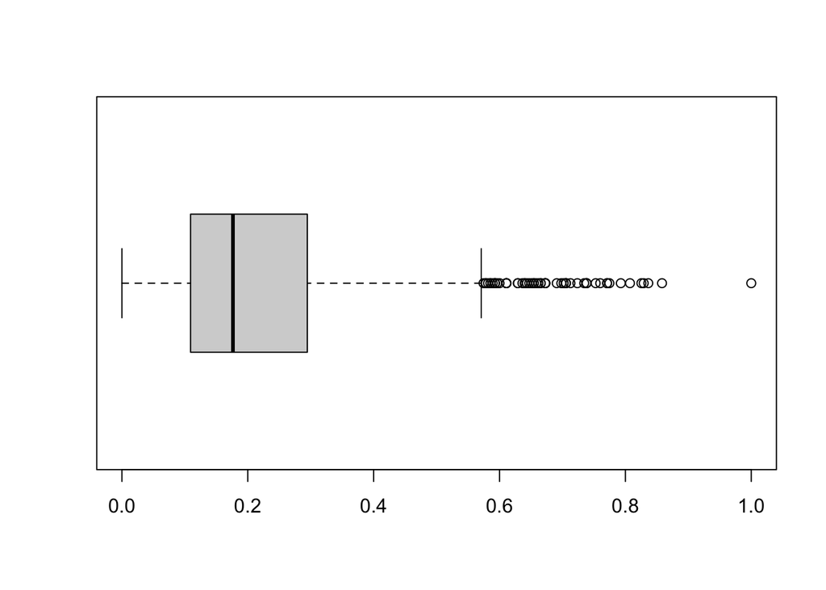

```
## $stats
##           [,1]
## [1,] 0.0000000
## [2,] 0.1090909
## [3,] 0.1763636
## [4,] 0.2945455
## [5,] 0.5709091
##
## $n
## [1] 1340
##
## $conf
##           [,1]
## [1,] 0.1683590
## [2,] 0.1843683
##
## $out
##  [1] 0.6727273 0.6727273 0.6290909 0.6436364 0.8581818 0.5818182 0.7745455
##  [8] 0.6509091 0.5890909 0.8072727 0.6581818 0.7018182 0.5963636 1.0000000
## [15] 0.7381818 0.8363636 0.7054545 0.7600000 0.5927273 0.6000000 0.7527273
## [22] 0.6545455 0.6618182 0.7236364 0.6654545 0.7927273 0.7054545 0.6109091
## [29] 0.6400000 0.6109091 0.6472727 0.5854545 0.7127273 0.5854545 0.7345455
## [36] 0.7381818 0.7054545 0.5781818 0.6290909 0.6400000 0.5745455 0.6909091
## [43] 0.8290909 0.6109091 0.6545455 0.6654545 0.6727273 0.6981818 0.7709091
## [50] 0.7709091 0.5927273 0.6727273 0.6109091 0.5781818 0.8254545 0.6363636
## [57] 0.7381818 0.5927273
##
## $group
##  [1] 1 1 1 1 1 1 1 1 1 1 1 1 1 1 1 1 1 1 1 1 1 1 1 1 1 1 1 1 1 1 1 1 1 1 1 1 1 1
## [39] 1 1 1 1 1 1 1 1 1 1 1 1 1 1 1 1 1 1 1 1
##
## $names
## [1] "1"
```

```r
(box <- boxplot(nba_1h$PTS, horizontal = TRUE))
```

```r
box$stats
```

```
##           [,1]
## [1,] 0.0000000
## [2,] 0.1090909
## [3,] 0.1763636
## [4,] 0.2945455
## [5,] 0.5709091
```

```r
fivenum(nba_1h$PTS)
```

```
## [1] 0.0000000 0.1090909 0.1763636 0.2945455 1.0000000
```

```r
 ?fivenum
#
# #added this a predictor versus replacing the numeric version
(nba_1h$PTS_f <- cut(nba_1h$PTS,c(-1,0.1763636,1),labels = c(0,1)))
```

```
##    [1] 1 1 0 1 0 0 1 1 0 0 0 0 0 1 0 0 0 0 1 1 1 1 1 1 1 1 1 1 1 1 1 1 1 1 0 1 0
##   [38] 1 1 1 0 0 0 0 0 0 1 0 0 0 0 0 0 0 0 0 0 0 0 0 0 0 0 1 0 1 1 1 1 1 1 1 1 0
##   [75] 0 1 1 1 1 1 1 0 1 0 1 1 0 0 1 1 1 1 0 0 1 0 0 1 0 0 0 0 0 0 0 0 0 0 0 0 0
##  [112] 0 0 0 0 0 0 0 1 0 1 1 1 1 1 1 1 1 1 1 1 0 1 1 1 1 1 1 1 1 1 0 1 0 1 0 0 0
##  [149] 0 1 1 0 0 0 0 0 0 0 1 1 0 0 0 0 0 1 1 1 0 0 0 0 1 0 0 0 0 0 0 0 0 1 1 1 1
##  [186] 1 1 1 1 1 1 1 1 1 1 1 1 1 1 1 1 1 1 1 1 0 0 0 0 0 0 0 0 0 0 0 0 0 0 0 0 0
##  [223] 0 0 0 0 0 0 1 0 0 0 0 0 0 0 1 1 1 1 1 1 1 1 1 1 1 1 1 1 1 1 1 0 1 0 1 1 0
##  [260] 0 0 0 0 0 0 0 0 0 0 0 1 0 1 1 1 1 0 1 1 1 1 1 1 1 1 0 1 1 0 1 1 1 1 0 0 0
##  [297] 0 0 0 0 1 1 1 0 0 0 0 0 0 0 0 0 0 0 1 1 1 1 1 1 1 1 1 1 1 1 1 1 0 1 1 1 1
##  [334] 0 0 0 0 0 0 0 0 0 0 0 0 0 0 0 0 0 0 0 1 1 1 1 1 1 1 1 1 1 1 1 1 1 1 0 0 0
##  [371] 1 1 1 1 1 1 1 0 0 0 1 0 0 0 1 0 0 1 0 0 0 0 0 0 0 0 0 0 0 0 1 1 1 1 0 1 1
##  [408] 1 1 0 1 1 1 1 1 0 1 1 1 1 0 1 1 0 0 0 0 1 1 0 0 0 0 0 0 0 0 0 0 0 0 0 1 1
##  [445] 1 1 1 0 1 1 1 0 0 1 1 1 0 0 0 1 0 1 0 1 0 1 1 0 1 0 0 0 0 0 0 0 0 0 0 0 0
##  [482] 0 0 0 0 0 0 0 0 0 1 1 1 1 1 1 1 1 1 1 1 1 1 1 1 1 1 1 0 0 0 1 1 1 1 1 0 1
##  [519] 0 0 0 0 0 0 0 0 0 0 0 0 0 0 0 0 0 0 1 1 1 1 1 0 0 1 1 1 1 1 1 1 1 1 1 1 1
```

[output cut: 23 more lines]

```r
#
str(nba_1h)
```

```
## Classes 'data.table' and 'data.frame':   1340 obs. of  21 variables:
##  $ Name       : chr  "Brandon Ingram" "Andrew Harrison" "JaKarr Sampson" "Malik Sealy" ...
##  $ GP         : num  0.352 0.338 0.887 0.662 0.521 ...
##  $ MIN        : num  0.643 0.63 0.323 0.225 0.222 ...
##  $ PTS        : num  0.244 0.236 0.164 0.182 0.138 ...
##  $ FGM        : num  0.232 0.172 0.172 0.202 0.131 ...
##  $ FGA        : num  0.358 0.311 0.205 0.247 0.116 ...
##  $ FG.        : num  0.218 0.116 0.369 0.377 0.573 ...
##  $ X3P.Made   : num  0.2174 0.3043 0.1739 0.0435 0 ...
##  $ X3PA       : num  0.3231 0.4308 0.2615 0.0769 0.0154 ...
##  $ FTM        : num  0.208 0.338 0.117 0.117 0.169 ...
##  $ FTA        : num  0.225 0.333 0.127 0.127 0.186 ...
##  $ FT.        : num  0.699 0.765 0.67 0.689 0.674 0.732 0.811 0.875 0.714 0.678 ...
##  $ OREB       : num  0.1321 0.0943 0.0943 0.1887 0.1887 ...
##  $ DREB       : num  0.3404 0.1915 0.1596 0.0745 0.1383 ...
##  $ REB        : num  0.279 0.154 0.14 0.118 0.162 ...
##  $ AST        : num  0.1792 0.3491 0.0943 0.0755 0.0283 ...
##  $ STL        : num  0.16 0.44 0.2 0.24 0.12 0.16 0.08 0.08 0.12 0.08 ...
##  $ BLK        : num  0.1026 0.1282 0.0769 0.0256 0.1026 ...
##  $ TOV        : num  0.279 0.349 0.209 0.209 0.163 ...
##  $ TARGET_5Yrs: num  0 0 0 1 1 0 1 1 0 0 ...
##  $ PTS_f      : Factor w/ 2 levels "0","1": 2 2 1 2 1 1 2 2 1 1 ...
##  - attr(*, ".internal.selfref")=<externalptr>
```

```r
nba_1h
```

```
##                  Name        GP       MIN       PTS       FGM       FGA
##    1:  Brandon Ingram 0.3521127 0.6428571 0.2436364 0.2323232 0.3578947
##    2: Andrew Harrison 0.3380282 0.6296296 0.2363636 0.1717172 0.3105263
##    3:  JaKarr Sampson 0.8873239 0.3227513 0.1636364 0.1717172 0.2052632
##    4:     Malik Sealy 0.6619718 0.2248677 0.1818182 0.2020202 0.2473684
##    5:     Matt Geiger 0.5211268 0.2222222 0.1381818 0.1313131 0.1157895
##   ---
## 1336:     Chris Smith 0.9718310 0.3359788 0.1309091 0.1313131 0.1473684
## 1337:     Brent Price 0.8028169 0.2513228 0.1163636 0.1212121 0.1736842
## 1338:    Marlon Maxey 0.4507042 0.2380952 0.1709091 0.1919192 0.1631579
## 1339: Litterial Green 0.5774648 0.2354497 0.1381818 0.1414141 0.1578947
## 1340:       Jon Barry 0.5070423 0.2275132 0.1345455 0.1313131 0.1894737
##             FG.   X3P.Made       X3PA        FTM        FTA   FT.       OREB
##    1: 0.2184369 0.21739130 0.32307692 0.20779221 0.22549020 0.699 0.13207547
##    2: 0.1162325 0.30434783 0.43076923 0.33766234 0.33333333 0.765 0.09433962
```

[output cut: 33 more lines]

```r
# #So no let's check the prevalence
(prevalence <- table(nba_1h$PTS_f )[[2]]/length(nba_1h$PTS_f ))
```

```
## [1] 0.5
```

### Initial Model Building: Decision Tree Style

```r
# Training, Evaluation, Tune, Evaluation, Test, Evaluation
# Divide up our data into three parts, Training, Tuning, and Test

#There is not a easy way to create 3 partitions using the createDataPartitions

#so we are going to use it twice. Mostly because we want to stratify on the variable we are working to predict. What does that mean?

#clean up our dataset a bit by dropping the original ranking variable and the nba name which we can't really use.

nba_dt <- nba_1h[,-c("Name","PTS")]
# view(nba_dt)
nba_dt
```

```
##              GP       MIN       FGM       FGA       FG.   X3P.Made       X3PA
##    1: 0.3521127 0.6428571 0.2323232 0.3578947 0.2184369 0.21739130 0.32307692
##    2: 0.3380282 0.6296296 0.1717172 0.3105263 0.1162325 0.30434783 0.43076923
##    3: 0.8873239 0.3227513 0.1717172 0.2052632 0.3687375 0.17391304 0.26153846
##    4: 0.6619718 0.2248677 0.2020202 0.2473684 0.3767535 0.04347826 0.07692308
##    5: 0.5211268 0.2222222 0.1313131 0.1157895 0.5731463 0.00000000 0.01538462
##   ---
## 1336: 0.9718310 0.3359788 0.1313131 0.1473684 0.3907816 0.00000000 0.03076923
## 1337: 0.8028169 0.2513228 0.1212121 0.1736842 0.2404810 0.04347826 0.10769231
## 1338: 0.4507042 0.2380952 0.1919192 0.1631579 0.6252505 0.00000000 0.00000000
## 1339: 0.5774648 0.2354497 0.1414141 0.1578947 0.4028056 0.00000000 0.03076923
## 1340: 0.5070423 0.2275132 0.1313131 0.1894737 0.2625251 0.17391304 0.20000000
##              FTM        FTA   FT.       OREB       DREB        REB        AST
##    1: 0.20779221 0.22549020 0.699 0.13207547 0.34042553 0.27941176 0.17924528
##    2: 0.33766234 0.33333333 0.765 0.09433962 0.19148936 0.15441176 0.34905660
```

[output cut: 21 more lines]

```r
part_index_1 <- caret::createDataPartition(nba_dt$PTS_f,
                                           times=1,
                                           p = 0.70,
                                           groups=1,
                                           list=FALSE)
# View(part_index_1)
dim(nba_dt)
```

```
## [1] 1340   19
```

```r
train <- nba_dt[part_index_1,]
tune_and_test <- nba_dt[-part_index_1, ]

#The we need to use the function again to create the tuning set

tune_and_test_index <- createDataPartition(tune_and_test$PTS_f,
                                           p = .5,
                                           list = FALSE,
                                           times = 1)

tune <- tune_and_test[tune_and_test_index, ]
test <- tune_and_test[-tune_and_test_index, ]


dim(train)
```

```
## [1] 938  19
```

```r
dim(tune)
```

```
## [1] 202  19
```

```r
dim(test)
```

```
## [1] 200  19
```

#### Using Caret package to fit a C5.0 version of a decision tree

Setting up the cross validation [Caret_Documentation](http://topepo.github.io/caret/train-models-by-tag.html#Tree_Based_Model)

```r
#Cross validation process

fitControl <- trainControl(method = "repeatedcv",
                          number = 10,
                          repeats = 5,
                          returnResamp="all")

# number - number of folds
# repeats - number of times the CV is repeated, here it's 5 take the average of
# those 5 repeats


# Choose the features and classes
```

#### Training and Evaluation

```r
features <- train[,-"PTS_f"]
target <- train[,"PTS_f"]

str(target)
```

```
## Classes 'data.table' and 'data.frame':   938 obs. of  1 variable:
##  $ PTS_f: Factor w/ 2 levels "0","1": 2 2 1 2 1 1 2 1 1 1 ...
##  - attr(*, ".internal.selfref")=<externalptr>
```

```r
set.seed(1984)
nba_mdl <- train(x=features,
                y=target$PTS_f,
                trControl=fitControl,
                method="C5.0",
                verbose=TRUE)

nba_mdl
```

```
## C5.0
##
## 938 samples
##  18 predictor
##   2 classes: '0', '1'
##
## No pre-processing
## Resampling: Cross-Validated (10 fold, repeated 5 times)
## Summary of sample sizes: 844, 845, 844, 844, 844, 844, ...
## Resampling results across tuning parameters:
##
##   model  winnow  trials  Accuracy   Kappa
##   rules  FALSE    1      0.9652456  0.9304881
##   rules  FALSE   10      0.9744152  0.9488299
##   rules  FALSE   20      0.9731363  0.9462720
##   rules   TRUE    1      0.9633285  0.9266572
##   rules   TRUE   10      0.9699472  0.9398939
##   rules   TRUE   20      0.9686660  0.9373313
##   tree   FALSE    1      0.9648201  0.9296366
##   tree   FALSE   10      0.9737701  0.9475389
##   tree   FALSE   20      0.9765429  0.9530848
##   tree    TRUE    1      0.9641795  0.9283593
##   tree    TRUE   10      0.9688879  0.9377771
##   tree    TRUE   20      0.9699471  0.9398951
##
## Accuracy was used to select the optimal model using the largest value.
## The final values used for the model were trials = 20, model = tree and winnow
##  = FALSE.
```

Tune and Evaluation

```r
nba_predict = predict(nba_mdl,tune,type= "raw")

confusionMatrix(as.factor(nba_predict),
                as.factor(tune$PTS_f),
                dnn=c("Prediction", "Actual"),
                mode = "sens_spec")
```

```
## Confusion Matrix and Statistics
##
##           Actual
## Prediction   0   1
##          0 100   1
##          1   1 100
##
##                Accuracy : 0.9901
##                  95% CI : (0.9647, 0.9988)
##     No Information Rate : 0.5
##     P-Value [Acc > NIR] : <2e-16
##
##                   Kappa : 0.9802
##
##  Mcnemar's Test P-Value : 1
##
##             Sensitivity : 0.9901
##             Specificity : 0.9901
##          Pos Pred Value : 0.9901
##          Neg Pred Value : 0.9901
##              Prevalence : 0.5000
##          Detection Rate : 0.4950
##    Detection Prevalence : 0.5000
##       Balanced Accuracy : 0.9901
##
##        'Positive' Class : 0
##
```

```r
varImp(nba_mdl)
```

```
## C5.0 variable importance
##
##             Overall
## FGM         100.000
## FGA         100.000
## FTA         100.000
## FTM         100.000
## X3P.Made     99.447
## AST          98.445
## DREB         98.111
## FT.          64.180
## MIN          62.291
## STL          45.712
## OREB         41.486
## BLK          33.253
## FG.          27.807
## REB          23.696
## X3PA         23.247
## GP           17.801
## TOV           8.118
## TARGET_5Yrs   0.000
```

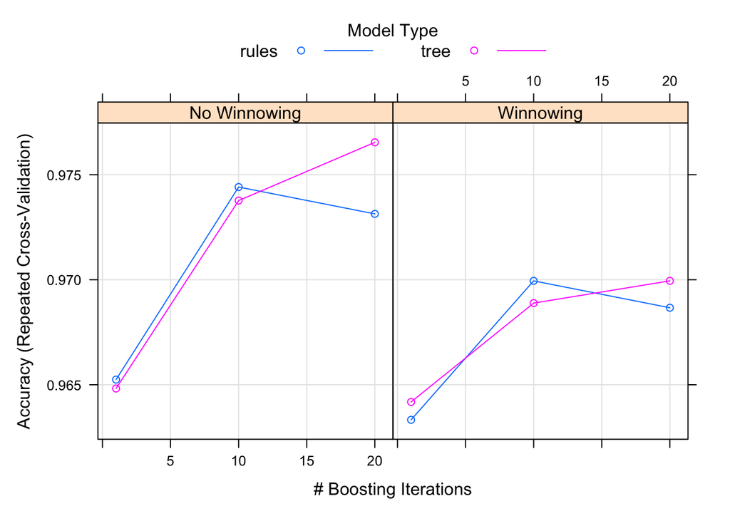

```r
plot(nba_mdl)
```

```r
grid <- expand.grid(.winnow = c(TRUE,FALSE),
                    .trials=c(20,30,40),
                    .model=c("tree","rules"))
set.seed(1984)
nba_mdl_tune <- train(x=features,
                y=target$PTS_f,
                tuneGrid=grid,
                trControl=fitControl,
                method="C5.0",
                verbose=TRUE)
nba_mdl_tune
```

```
## C5.0
##
## 938 samples
##  18 predictor
##   2 classes: '0', '1'
##
## No pre-processing
## Resampling: Cross-Validated (10 fold, repeated 5 times)
## Summary of sample sizes: 844, 845, 844, 844, 844, 844, ...
## Resampling results across tuning parameters:
##
##   model  winnow  trials  Accuracy   Kappa
##   rules  FALSE   20      0.9731363  0.9462720
##   rules  FALSE   30      0.9765452  0.9530897
##   rules  FALSE   40      0.9765475  0.9530949
##   rules   TRUE   20      0.9690915  0.9381823
##   rules   TRUE   30      0.9701577  0.9403145
##   rules   TRUE   40      0.9699472  0.9398953
##   tree   FALSE   20      0.9765429  0.9530848
##   tree   FALSE   30      0.9759092  0.9518175
##   tree   FALSE   40      0.9767603  0.9535196
##   tree    TRUE   20      0.9699471  0.9398951
##   tree    TRUE   30      0.9714411  0.9428823
##   tree    TRUE   40      0.9703681  0.9407375
##
## Accuracy was used to select the optimal model using the largest value.
## The final values used for the model were trials = 40, model = tree and winnow
##  = FALSE.
```

```r
nba_mdl
```

```
## C5.0
##
## 938 samples
##  18 predictor
##   2 classes: '0', '1'
##
## No pre-processing
## Resampling: Cross-Validated (10 fold, repeated 5 times)
## Summary of sample sizes: 844, 845, 844, 844, 844, 844, ...
## Resampling results across tuning parameters:
##
##   model  winnow  trials  Accuracy   Kappa
##   rules  FALSE    1      0.9652456  0.9304881
##   rules  FALSE   10      0.9744152  0.9488299
##   rules  FALSE   20      0.9731363  0.9462720
##   rules   TRUE    1      0.9633285  0.9266572
##   rules   TRUE   10      0.9699472  0.9398939
##   rules   TRUE   20      0.9686660  0.9373313
##   tree   FALSE    1      0.9648201  0.9296366
##   tree   FALSE   10      0.9737701  0.9475389
##   tree   FALSE   20      0.9765429  0.9530848
##   tree    TRUE    1      0.9641795  0.9283593
##   tree    TRUE   10      0.9688879  0.9377771
##   tree    TRUE   20      0.9699471  0.9398951
##
## Accuracy was used to select the optimal model using the largest value.
## The final values used for the model were trials = 20, model = tree and winnow
##  = FALSE.
```

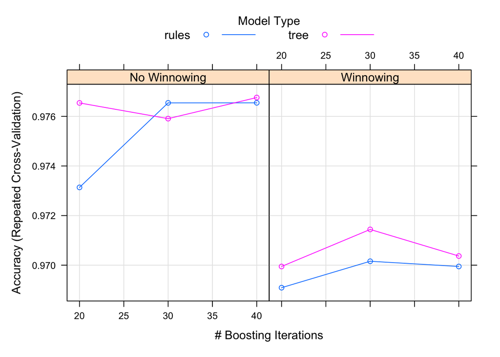

```r
plot(nba_mdl_tune)
```

```r
# Want to evaluation again with the tune data using the new model

nba_predict_tune = predict(nba_mdl_tune,tune,type= "raw")

confusionMatrix(as.factor(nba_predict_tune),
                as.factor(tune$PTS_f),
                dnn=c("Prediction", "Actual"),
                mode = "sens_spec")
```

```
## Confusion Matrix and Statistics
##
##           Actual
## Prediction   0   1
##          0 100   1
##          1   1 100
##
##                Accuracy : 0.9901
##                  95% CI : (0.9647, 0.9988)
##     No Information Rate : 0.5
##     P-Value [Acc > NIR] : <2e-16
##
##                   Kappa : 0.9802
##
##  Mcnemar's Test P-Value : 1
##
##             Sensitivity : 0.9901
##             Specificity : 0.9901
##          Pos Pred Value : 0.9901
##          Neg Pred Value : 0.9901
##              Prevalence : 0.5000
##          Detection Rate : 0.4950
##    Detection Prevalence : 0.5000
##       Balanced Accuracy : 0.9901
##
##        'Positive' Class : 0
##
```

### Test

```r
nba_predict_test = predict(nba_mdl_tune,test,type= "raw")

confusionMatrix(as.factor(nba_predict_test),
                as.factor(test$PTS_f),
                dnn=c("Prediction", "Actual"),
                mode = "sens_spec")
```

```
## Confusion Matrix and Statistics
##
##           Actual
## Prediction  0  1
##          0 99  4
##          1  1 96
##
##                Accuracy : 0.975
##                  95% CI : (0.9426, 0.9918)
##     No Information Rate : 0.5
##     P-Value [Acc > NIR] : <2e-16
##
##                   Kappa : 0.95
##
##  Mcnemar's Test P-Value : 0.3711
##
##             Sensitivity : 0.9900
##             Specificity : 0.9600
##          Pos Pred Value : 0.9612
##          Neg Pred Value : 0.9897
##              Prevalence : 0.5000
##          Detection Rate : 0.4950
##    Detection Prevalence : 0.5150
##       Balanced Accuracy : 0.9750
##
##        'Positive' Class : 0
##
```

#### Summary/Findings

Through the analysis above, my goal was to find out if players in the NBA with longer careers had better performance. More specifically, I wanted to see whether rookies or players with more experience were adding the most value to the team. And consequently, allowing sports leagues like the NBA to decide whether they want to cycle in rookies/newbies and cycle out old players more frequently. For this reason I made my target variable points per game (PTS). However after tuning and evaluating my data, I found that the longevity of career (ie. greater or less than 5 years) was the feature with the least importance in predicting performance or points per game. Instead, field goal attempts, field goals made, and free throw attempts, that were the most important features in predicting shooting performance. Some issues I encountered in this analysis process included system errors with loading certain packages (fixed by loading binary versions) and figuring out how to tune the hyper parameters as I am not too familiar with the C50 model.